# 資料結構

曾意儒 Yi-Ju Tseng

### 對應書本章節

[2 R 資料結構](http://yijutseng.github.io/DataScienceRBook/RDataStructure.html)

### 大綱

- 向量 Vector
- 列表 List
- 資料框 data.frame
- 屬性查詢函數

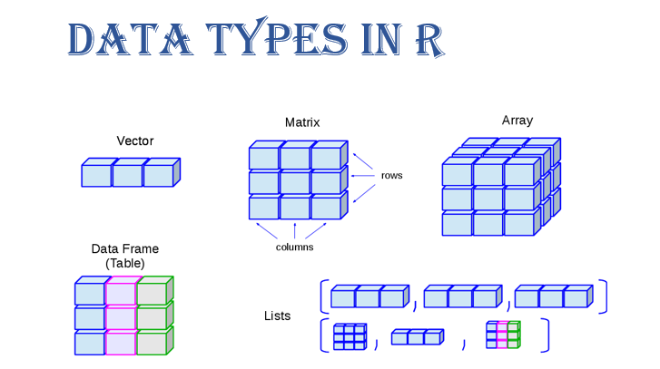

## 向量 Vector

- 一維資料
- 所有元素之**資料型態必須相同**
- `c()`函數 定義向量

```r
vec<-c('a','b','c','d','e')
```

- a~e: **元素(element)**
- 順序固定
  - `a`: 第**1**個元素
  - `b`: 第**2**個元素

### 向量元素之資料型態必須相同

- 在同一向量中，所有元素之**資料型態必須相同**
- 上述`vec`向量，元素均為文字型態
- 若放不同類別的資料進同一個向量，資料型態會被自動轉為相同

```r
a<-c(TRUE, "a",1)
str(a)
```

```
 chr [1:3] "TRUE" "a" "1"
```

### 向量 Vector 取值

若要將`vec`向量的第**4**個元素取出，可使用**向量名稱[元素位置]**:

```r
vec[4] ## 第4個元素
```

```
[1] "d"
```

也可同時取出多個元素

```r
vec[c(2,3)] ## 第2與第3個元素
```

```
[1] "b" "c"
```

### 向量 Vector 元素設定

```r
vec[3]
```

```
[1] "c"
```

```r
vec[3]<-'z' ##第三個元素值設定為“z”
vec[3]
```

```
[1] "z"
```

### 產生向量函數

若要產生連續向量，如1~20，可使用`:`來串連首字與最後一字

```r
1:20 ## c(1,2,...,19,20)
```

```
 [1]  1  2  3  4  5  6  7  8  9 10 11 12 13 14 15 16 17 18 19 20
```

### 產生向量函數 seq()函數

```r
seq(from=1,to=20,by=1) ##1~20，中間相隔1
```

```
 [1]  1  2  3  4  5  6  7  8  9 10 11 12 13 14 15 16 17 18 19 20
```

```r
seq(from=1,to=50,by=2) ##1~50，中間相隔2
```

```
 [1]  1  3  5  7  9 11 13 15 17 19 21 23 25 27 29 31 33 35 37 39 41 43 45
[24] 47 49
```

### 向量取值練習

- 新增一向量a，包含數字1到10
- 新增一向量b，包含數字1到20中的所有偶數
- 取出a向量的第4個元素
- 取出b向量的第5,6,7個元素

### 向量運算

向量也可直接做加減乘除運算，如

```r
numvec<-1:10 ## c(1,2,3,4,5,6,7,8,9,10)
numvec+3 ## 所有元素+3
```

```
 [1]  4  5  6  7  8  9 10 11 12 13
```

```r
numvec*2 ## 所有元素*2
```

```
 [1]  2  4  6  8 10 12 14 16 18 20
```

### 向量運算

向量和向量也可做運算，如

```r
numvec1<-1:3 ## c(1,2,3)
numvec2<-4:6 ## c(4,5,6)
numvec1+numvec2
```

```
[1] 5 7 9
```

```r
numvec1*numvec2
```

```
[1]  4 10 18
```

### 向量運算練習

- a向量為1到6連續數字
- b向量是3到5的連續數字
- a+b =?

## 列表 list

- **向量**和**因子**都只能儲存一種元素
- 保有彈性: **列表list**
- 元素可分屬不同資料類別，
- **數值**、**文字**、**向量**、**因子**
- `list()`函數

### 列表 list

```r
listSample<-list(Students=c("Tom","Kobe","Emma"),
                 Year=2017,
                 Score=c(60,50,80,40),
                 School="CGU")
listSample
```

```
$Students
[1] "Tom"  "Kobe" "Emma"

$Year
[1] 2017

$Score
[1] 60 50 80 40

$School
[1] "CGU"
```

### 列表資料擷取

列表可用`$`符號做資料擷取

```r
listSample$Students ##取得listSample列表中的Students變量
```

```
[1] "Tom"  "Kobe" "Emma"
```

### 列表資料擷取

- 若要取得**值**，要使用雙中括號`[[]]`

```r
listSample[[1]] ##第一個變量的值
```

```
[1] "Tom"  "Kobe" "Emma"
```

- 只使用單中括號`[]`，回傳的資料型態會是**列表list**

```r
listSample[1] ##第一個變量（列表型態）
```

```
$Students
[1] "Tom"  "Kobe" "Emma"
```

### 列表list取值練習

- 依投影片，新增listSample列表
- 取出分數資料 (值)
  - 方法一
  - 方法二
- 取出分數資料 （列表）

### 列表資料編輯設定

列表資料和向量資料一樣，可重新編輯設定

```r
listSample[[1]]
```

```
[1] "Tom"  "Kobe" "Emma"
```

```r
listSample[[1]]<-c("小明","大雄","胖虎","小新","大白") ##將Students變量重新設定
listSample[[1]]
```

```
[1] "小明" "大雄" "胖虎" "小新" "大白"
```

### 列表資料編輯設定

列表資料也能用`$`符號與`<-`變數設定符號新增

```r
listSample$Gender<-c("M","F","M","F","M") ##新增Gender變量，並設定向量值
```

### 列表list資料編輯練習

- 依投影片，新增listSample列表
- 發現學校名稱打錯了，應該是CGUST，請改列表資料
- 在列表中新增學期資料，並設定為上學期

### 列表資料名稱修改

列表資料的名稱修改可考慮搭配`names()`函數與向量元素修改

```r
#檢查原本的名字
names(listSample) #original name
```

```
[1] "Students" "Year"     "Score"    "School"   "Gender"
```

```r
#將第一個名字改成NewName
names(listSample)[1]<-"NewName"
#檢查新的名字
names(listSample) #modified name
```

```
[1] "NewName" "Year"    "Score"   "School"  "Gender"
```

### 列表資料中的向量也可新增元素

把原有`listSample$Gender`的向量取出，並加上`?`，最後寫回`listSample$Gender`

```r
listSample$Gender
```

```
[1] "M" "F" "M" "F" "M"
```

```r
listSample$Gender<-c(listSample$Gender,"?")
listSample$Gender
```

```
[1] "M" "F" "M" "F" "M" "?"
```

## 資料框 data.frame

- 二維資料格式 (Excel試算表)
- 由欄位（Column）和列（Row）組成
- 使用`data.frame()`來創建新的資料框

```r
StuDF <- data.frame(StuID=c(1,2,3), ##欄位名稱=欄位值
                  name=c("小明","大雄","胖虎"),
                  score=c(80,60,90))
StuDF
```

```
  StuID name score
1     1 小明    80
2     2 大雄    60
3     3 胖虎    90
```

### 資料框 data.frame

- 每列：觀察值 / 每欄：變數
- 欄位需有名稱
  - StuID, name, score
  - 若沒有設定，自動指派V1~Vn
- 欄位的資料型態相同
- 每一列有列名
  - 依序指派1~n作為列名
- 檢查欄位名稱 `colnames()`
- 檢查欄位列名，`rownames()`

```r
colnames(StuDF) ##欄名
```

```
[1] "StuID" "name"  "score"
```

```r
rownames(StuDF) ##列名
```

```
[1] "1" "2" "3"
```

### 資料框 data.frame

如需檢查個欄位之資料型別，可使用`str()`函數

**解釋iris資料框**???

```r
str(iris)
```

```
'data.frame':   150 obs. of  5 variables:
 $ Sepal.Length: num  5.1 4.9 4.7 4.6 5 5.4 4.6 5 4.4 4.9 ...
 $ Sepal.Width : num  3.5 3 3.2 3.1 3.6 3.9 3.4 3.4 2.9 3.1 ...
 $ Petal.Length: num  1.4 1.4 1.3 1.5 1.4 1.7 1.4 1.5 1.4 1.5 ...
 $ Petal.Width : num  0.2 0.2 0.2 0.2 0.2 0.4 0.3 0.2 0.2 0.1 ...
 $ Species     : Factor w/ 3 levels "setosa","versicolor",..: 1 1 1 1 1 1 1 1 1 1 ...
```

### 資料框資料擷取

資料框可用`$`符號做**欄位**資料擷取

```r
iris$Species ##取得iris資料框中的Species欄位
```

```
  [1] setosa     setosa     setosa     setosa     setosa     setosa
  [7] setosa     setosa     setosa     setosa     setosa     setosa
 [13] setosa     setosa     setosa     setosa     setosa     setosa
 [19] setosa     setosa     setosa     setosa     setosa     setosa
 [25] setosa     setosa     setosa     setosa     setosa     setosa
 [31] setosa     setosa     setosa     setosa     setosa     setosa
 [37] setosa     setosa     setosa     setosa     setosa     setosa
 [43] setosa     setosa     setosa     setosa     setosa     setosa
 [49] setosa     setosa     versicolor versicolor versicolor versicolor
 [55] versicolor versicolor versicolor versicolor versicolor versicolor
 [61] versicolor versicolor versicolor versicolor versicolor versicolor
 [67] versicolor versicolor versicolor versicolor versicolor versicolor
 [73] versicolor versicolor versicolor versicolor versicolor versicolor
 [79] versicolor versicolor versicolor versicolor versicolor versicolor
 [85] versicolor versicolor versicolor versicolor versicolor versicolor
 [91] versicolor versicolor versicolor versicolor versicolor versicolor
 [97] versicolor versicolor versicolor versicolor virginica  virginica
[103] virginica  virginica  virginica  virginica  virginica  virginica
[109] virginica  virginica  virginica  virginica  virginica  virginica
[115] virginica  virginica  virginica  virginica  virginica  virginica
[121] virginica  virginica  virginica  virginica  virginica  virginica
[127] virginica  virginica  virginica  virginica  virginica  virginica
[133] virginica  virginica  virginica  virginica  virginica  virginica
[139] virginica  virginica  virginica  virginica  virginica  virginica
[145] virginica  virginica  virginica  virginica  virginica  virginica
Levels: setosa versicolor virginica
```

### 資料框資料編輯

資料框可用`$`符號做**欄位**資料擷取後，當成向量，並使用**[]**做資料編輯。

```r
iris$Species[2]<-"versicolor"
head(iris$Species)
```

```
[1] setosa     versicolor setosa     setosa     setosa     setosa
Levels: setosa versicolor virginica
```

### 資料框資料編輯練習

- iris$Time<-1 會發生什麼事情?

### 資料框欄位刪除

若需刪除某欄位，可將欄位值設定為`NULL`

```r
iris$Species<-NULL ##刪除Species欄位
head(iris)
```

```
  Sepal.Length Sepal.Width Petal.Length Petal.Width
1          5.1         3.5          1.4         0.2
2          4.9         3.0          1.4         0.2
3          4.7         3.2          1.3         0.2
4          4.6         3.1          1.5         0.2
5          5.0         3.6          1.4         0.2
6          5.4         3.9          1.7         0.4
```

## 資料表 data.table

- data.frame資料框型別的延伸
- 需安裝**data.table** package
- 讀取大型資料的速度快上數倍
- 進階處理語言
- **探索式資料分析**再介紹

## 資料屬性查詢函數

資料屬性可透過下列函數查詢:

- 長度 `length()`
- 資料型態 `class()`
- 各類資料計數 `table()`
- 總覽資料 `str()`

### length()

透過`length()`函數可顯示資料長度，包括向量與資料框，若資料行態為資料框，則會顯示行（欄位）數

```r
length(islands)
```

```
[1] 48
```

```r
length(USArrests)
```

```
[1] 4
```

### class()

使用`class()`函數可知道變數類別

```r
class(1)
```

```
[1] "numeric"
```

```r
class("Test")
```

```
[1] "character"
```

```r
class(Sys.Date())
```

```
[1] "Date"
```

### table()

使用`table()`函數可知道向量中每個值出現幾次

```r
iris$Species[1:10] ##原始值，印出第1~10個元素
```

[output not shown]

```r
table(iris$Species) ##統計結果
```

```
< table of extent 0 >
```

### str()

使用`str()`函數可總覽變數資訊

```r
str(USArrests)
```

```
'data.frame':   50 obs. of  4 variables:
 $ Murder  : num  13.2 10 8.1 8.8 9 7.9 3.3 5.9 15.4 17.4 ...
 $ Assault : int  236 263 294 190 276 204 110 238 335 211 ...
 $ UrbanPop: int  58 48 80 50 91 78 77 72 80 60 ...
 $ Rape    : num  21.2 44.5 31 19.5 40.6 38.7 11.1 15.8 31.9 25.8 ...
```

### str()

使用`str()`函數可總覽變數資訊

```r
str(listSample)
```

```
List of 5
 $ NewName: chr [1:5] "小明" "大雄" "胖虎" "小新" ...
 $ Year   : num 2017
 $ Score  : num [1:4] 60 50 80 40
 $ School : chr "CGU"
 $ Gender : chr [1:6] "M" "F" "M" "F" ...
```

### 資料探索練習

- R的內建資料集**airquality**內有幾筆觀察值？每筆觀察值內有幾個變數？
- R的內建資料集**airquality**裡面的**Month**變數中，各月份出現的次數是多少？